# **Panorama da inflação**

Os principais índices de inflação do Brasil, apontam em julho de 2000 um avanço da inflação de em média **1.52%**. Com esse resultado, no ano a inflação acumula uma variação média positiva de **3.11%**, e em 12 meses uma variação média acumulada de **9.26%**.

[output not shown]

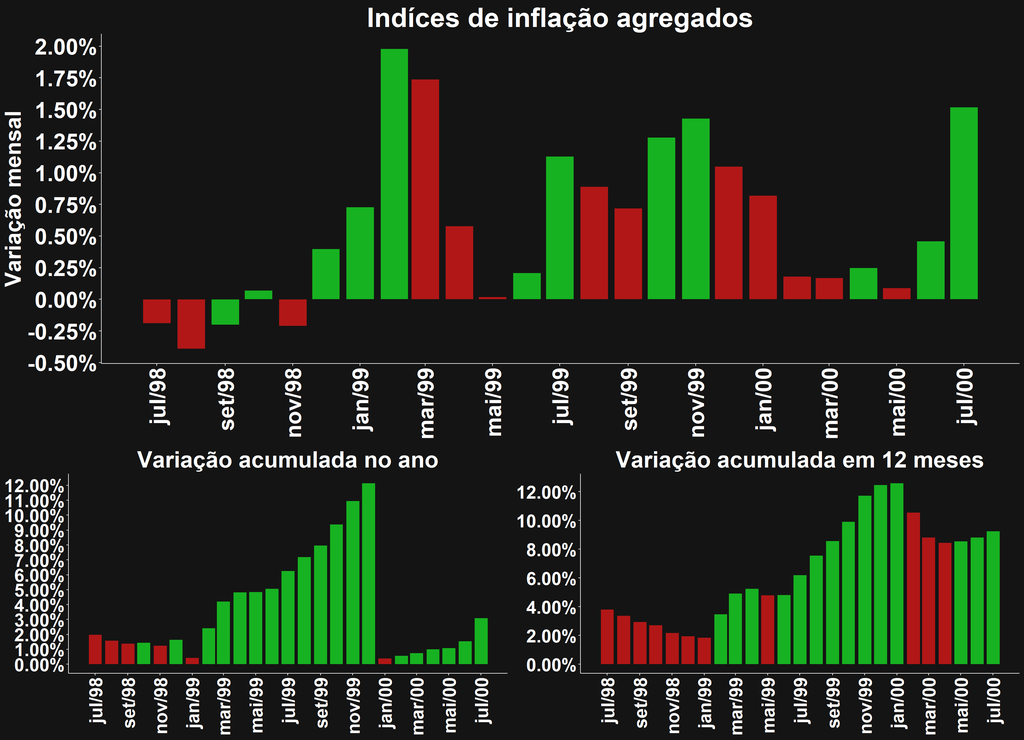

Índices selecionados para a média: IPCA, INPC e IGP-M.

# IPCA

O Indíce de Preços ao Consumidor Amplo (IPCA) variou 1.61% em julho, valor superior ao mesmo período do ano anterior quando apresentou uma taxa de 1.09%. Com esse resultado o indíce acumula no ano uma variação positiva de 3.28%, e em 12 meses uma variação positiva de 7.06%.

|  | 07/1999 | 06/2000 | 07/2000 |
| --- | --- | --- | --- |
| Variação mensal | 1.09% | 0.23% | 1.61% |
| Variação acumulada no ano | 5.09% | 1.64% | 3.28% |
| Variação acumulada em 12 meses | 4.57% | 6.51% | 7.06% |

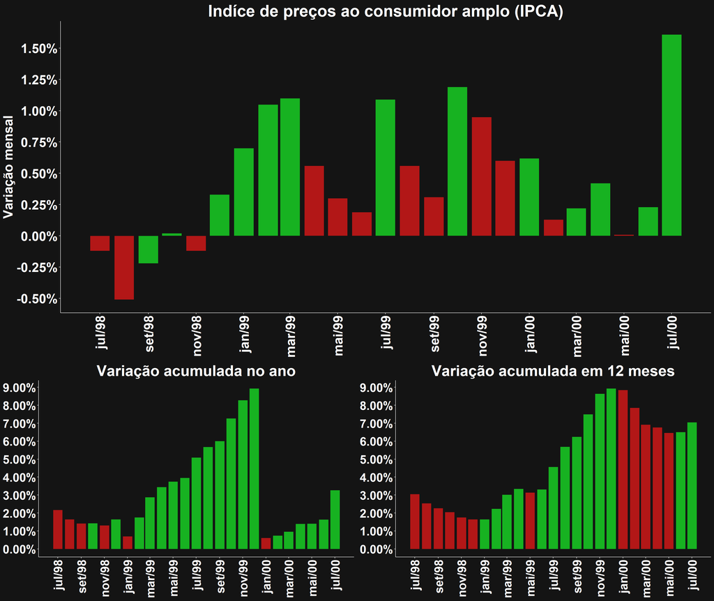

|  | Variação mensal | Variação acumulada no ano | Peso mensal |
| --- | --- | --- | --- |
| Alimentação e bebidas | 1.78% | 0.97% | 22.07% |
| Habitação | 1.29% | 2.09% | 15.88% |
| Artigos de residência | 0.33% | 2.21% | 5.9% |
| Vestuário | 0.79% | 0.86% | 5.53% |
| Transportes | 2.98% | 6.25% | 21.12% |
| Saúde e cuidados pessoais | 0.48% | 2.12% | 11.34% |
| Despesas pessoais | 0.2% | 4.36% | 9.82% |
| Educação | -0.25% | 3.76% | 4.97% |
| Comunicação | 7.61% | 12.5% | 3.37% |

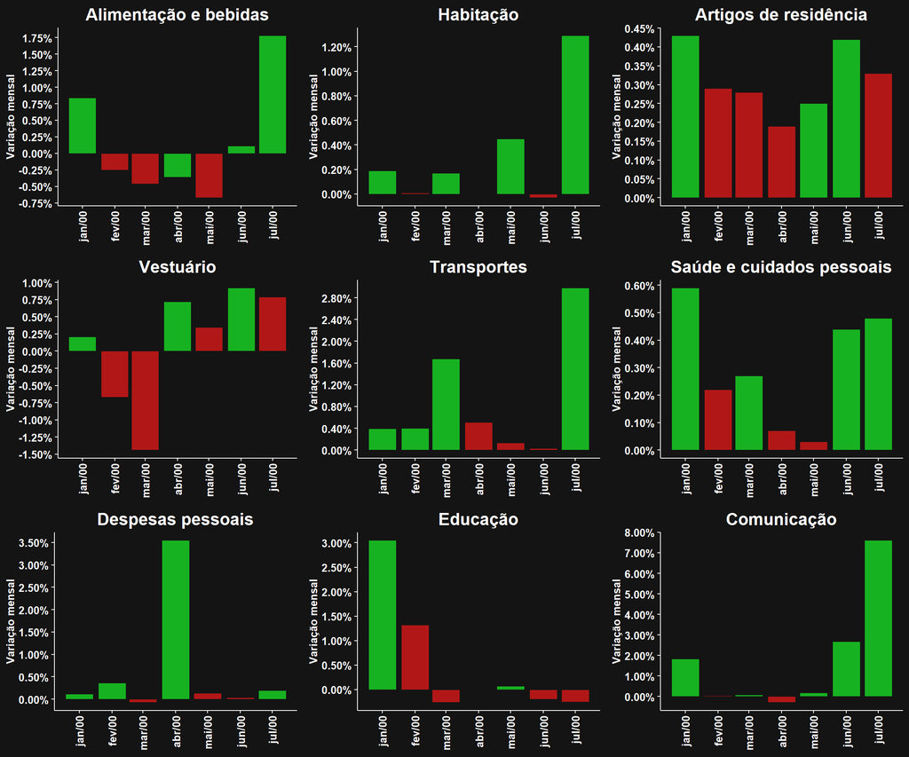

A nível de sub-itens os que mais influenciaram positivamente no resultado em relação ao seu peso foram Gasolina (10.27%%) e Telefone fixo (8.61%%), e negativamente Refeição (-1.05%%) e Revista não técnica (-12.01%%).

|  | Variação mensal | Variação acumulada no ano | Peso mensal |
| --- | --- | --- | --- |
| Telefone fixo | 8.61% | 13.67% | 2.89% |
| Energia elétrica residencial | 4.85% | 6.77% | 3.34% |
| Leite pasteurizado | 13.34% | 29.31% | 1.4% |
| Gasolina | 10.27% | 12.18% | 3.58% |

|  | Variação mensal | Variação acumulada no ano | Peso mensal |
| --- | --- | --- | --- |
| Aluguel residencial | -0.22% | -1.81% | 5.45% |
| Condomínio | -0.74% | 0.8% | 1.92% |
| Refeição | -1.05% | 2.12% | 2.37% |
| Revista não técnica | -12.01% | -11.61% | 0.18% |

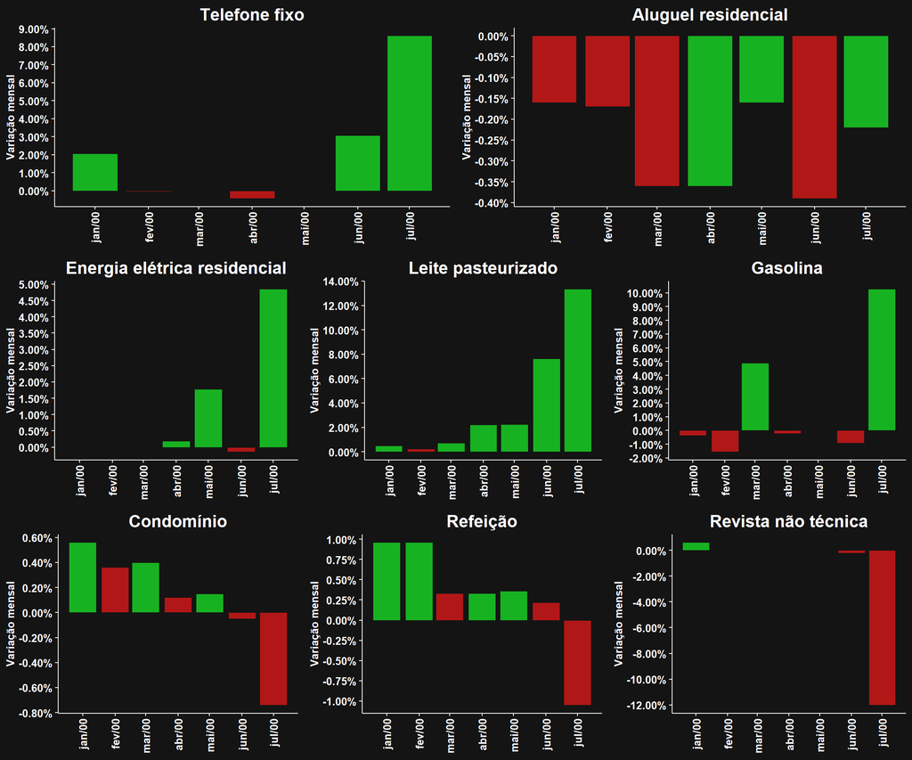

# INPC

O Indíce Nacional de Preços ao Consumidor (INPC) variou 1.39% em julho, valor superior ao mesmo período do ano anterior quando apresentou uma taxa de 0.74%. Com esse resultado o indíce acumula no ano uma variação positiva de 2.54%, e em 12 meses uma variação positiva de 6.26%.

|  | 07/1999 | 06/2000 | 07/2000 |
| --- | --- | --- | --- |
| Variação mensal | 0.74% | 0.3% | 1.39% |
| Variação acumulada no ano | 4.63% | 1.13% | 2.54% |
| Variação acumulada em 12 meses | 4.16% | 5.58% | 6.26% |

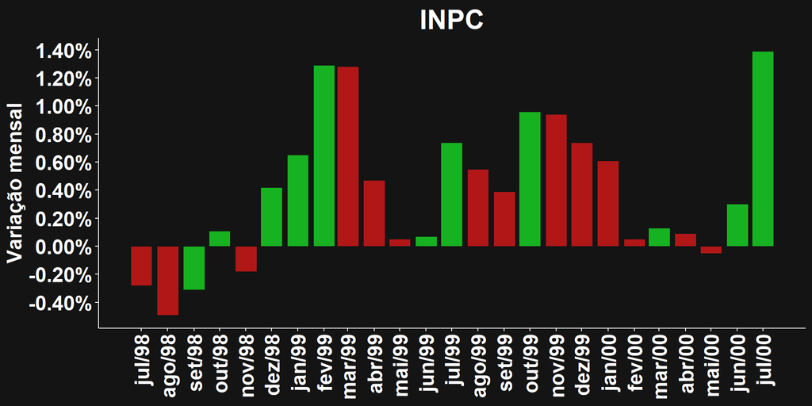

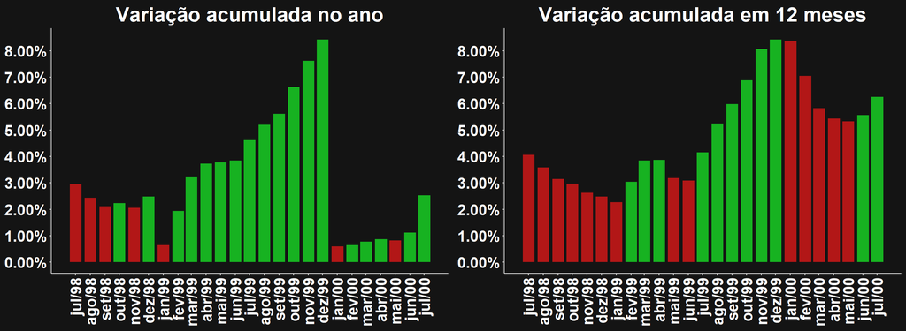

# IGP-M

O Indíce Geral de Preços de Mercado (IGP-M) variou 1.57% em julho, valor superior ao mesmo período do ano anterior quando apresentou uma taxa de 1.55%. Com esse resultado o indíce acumula no ano uma variação positiva de 3.51%, e em 12 meses uma variação positiva de 14.46%.

|  | 07/1999 | 06/2000 | 07/2000 |
| --- | --- | --- | --- |
| Variação mensal | 1.55% | 0.85% | 1.57% |
| Variação acumulada no ano | 9.05% | 1.91% | 3.51% |
| Variação acumulada em 12 meses | 9.92% | 14.43% | 14.46% |

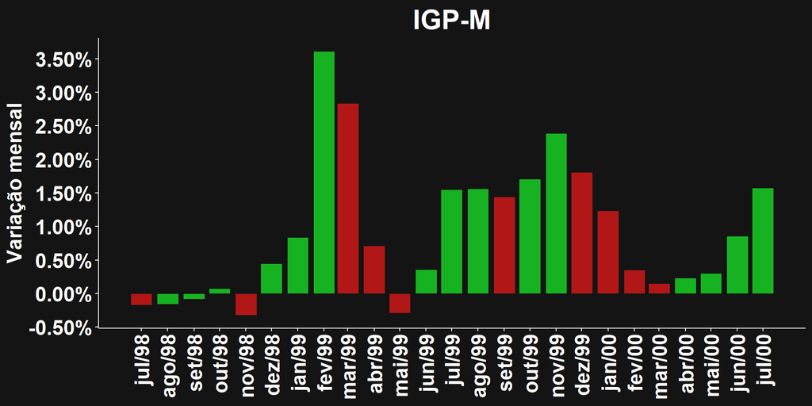

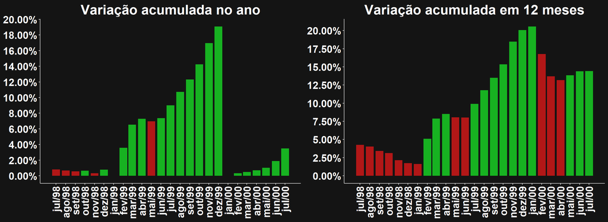

# IGP-DI

O Indíce Geral de Preços - Disponibilidade Interna (IGP-DI) variou 2.26% em julho, valor superior ao mesmo período do ano anterior quando apresentou uma taxa de 1.59%. Com esse resultado o indíce acumula no ano uma variação positiva de 4.43%, e em 12 meses uma variação positiva de 14.85%.

|  | 07/1999 | 06/2000 | 07/2000 |
| --- | --- | --- | --- |
| Variação mensal | 1.59% | 0.93% | 2.26% |
| Variação acumulada no ano | 8.95% | 2.12% | 4.43% |
| Variação acumulada em 12 meses | 10.83% | 14.1% | 14.85% |

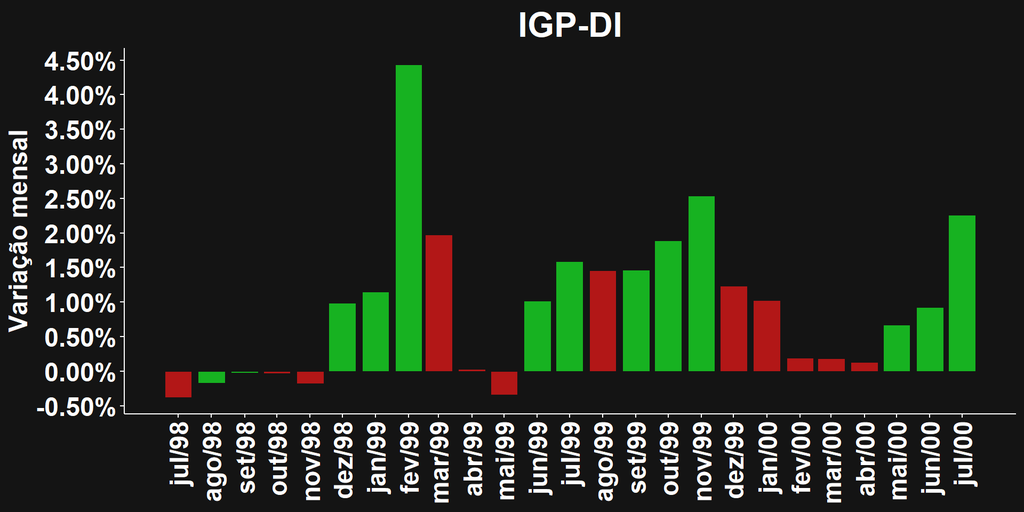

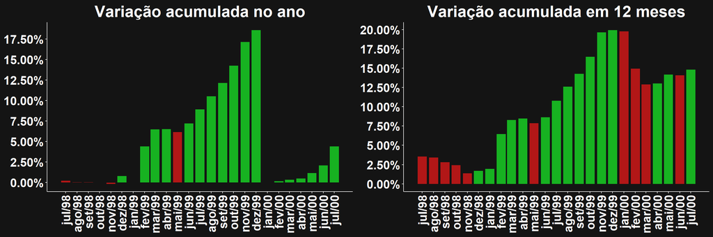

[output not shown]

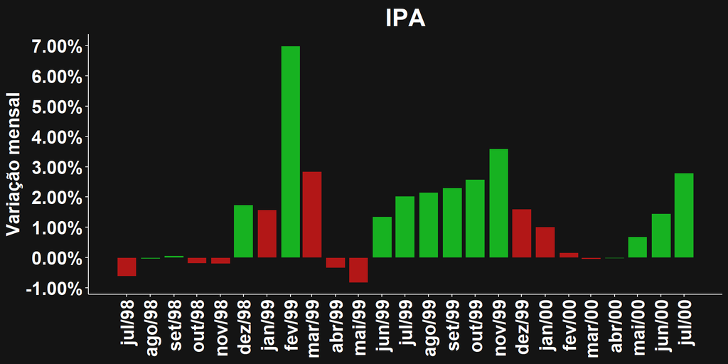

[figure not shown]

O Indíce de Preços ao Consumidor (IPC), integrante do IGP-DI com peso de 30%, apresentou variação de 1.91% em julho, valor superior ao mesmo período do ano anterior quando apresentou uma taxa de 1.2%. Com esse resultado o indíce acumula no ano uma variação positiva de 3.14%, e em 12 meses uma variação positiva de 7.67%.

|  | 07/1999 | 06/2000 | 07/2000 |
| --- | --- | --- | --- |
| Variação mensal | 1.2% | -0.01% | 1.91% |
| Variação acumulada no ano | 4.91% | 1.2% | 3.14% |
| Variação acumulada em 12 meses | 4.95% | 6.92% | 7.67% |

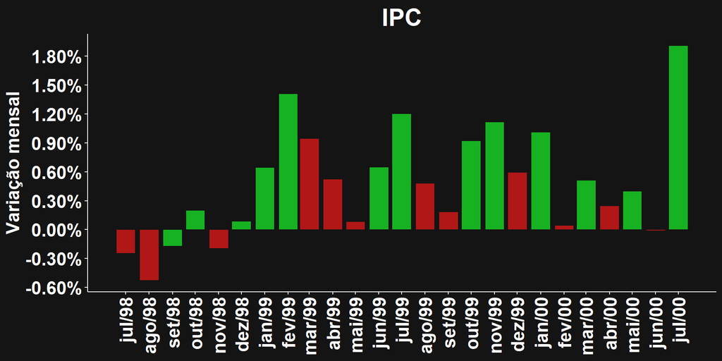

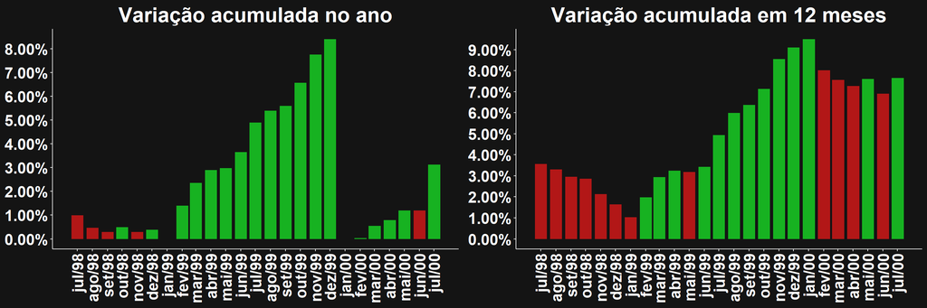

|  | 07/1999 | 06/2000 | 07/2000 |
| --- | --- | --- | --- |
| Variação mensal | 0.46% | 0.73% | 0.3% |
| Variação acumulada no ano | 3.83% | 4.07% | 4.38% |
| Variação acumulada em 12 meses | 4.65% | 10.53% | 10.36% |

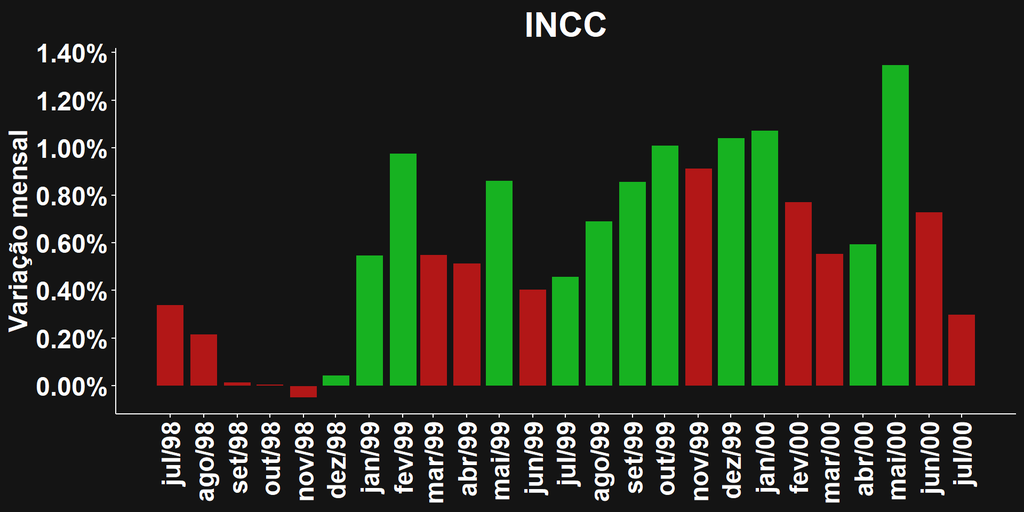

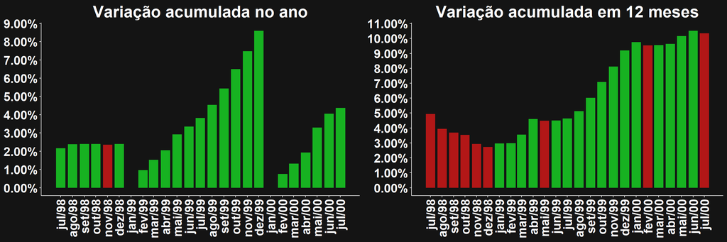

# Estatísticas

As estatísticas descritivas a seguir são feitas com base nos últimos 48 meses, e tem como objetivo possibilitar a avaliação do resultado observado em comparação aos períodos anteriores.

|  | Minimo | 1 Quartil | Mediana | Media | 3 Quartil | Maximo | Desvio Padrão |
| --- | --- | --- | --- | --- | --- | --- | --- |
| IPCA | -0.51% | 0.18% | 0.38% | 0.42% | 0.57% | 1.61% | 0.41% |
| INPC | -0.49% | 0.11% | 0.38% | 0.39% | 0.62% | 1.39% | 0.41% |
| IGP-M | -0.32% | 0.17% | 0.41% | 0.71% | 1.01% | 3.61% | 0.82% |
| IGP-DI | -0.38% | 0.12% | 0.5% | 0.71% | 1.05% | 4.44% | 0.89% |
| IPA | -0.82% | -0.03% | 0.41% | 0.9% | 1.58% | 6.99% | 1.35% |
| IPC | -0.52% | 0.12% | 0.41% | 0.46% | 0.65% | 1.91% | 0.54% |
| INCC | -0.5% | 0.25% | 0.53% | 0.53% | 0.86% | 1.35% | 0.38% |

Levando em consideração o desvio padrão de cada indíce, proporcionalmente os que mais se afastaram da média foram o IPCA, o IPC e o INPC.

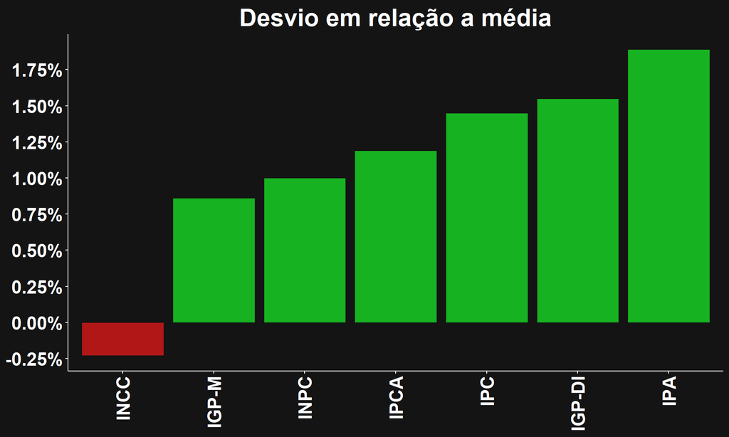

**João Victor Gomes**  
**jvg.santana@gmail.com**  
**[linkedin.com/in/jvictorgomes](https://www.linkedin.com/in/jvictorgomes/)**